# Projektarbeit Deep Learning

(Autor: Gustav Willig, Matr.197332)

Im vorliegenden Notebook wird anhand des Projekts Gesichtserkennung das Konzept des "Transfer-Learning" gezeigt.

Notebookstruktur:

1. Import aller benötigten Libraries
2. Festlegung der Daten
3. Zufallsverteilung der Daten
4. Aufbereitung der Daten
5. Anzeige der Daten
6. Neuronales Netz definieren
7. Training und Optimierung des neuronalen Netzes
8. Interpretation des Trainingserfolgs des besten Modells
9. Fazit

### 1. Import aller benötigten Libraries

```python
import os
#===Durch Aktivierung dieser Zeilen erfolgt die Berechnung auf der CPU anstatt auf der GPU
# os.environ['CUDA_VISIBLE_DEVICES'] = '-1'
#=======================
import keras
from keras.models import Model,Sequential
from keras.utils import np_utils
from keras.optimizers import RMSprop, SGD
from keras.callbacks import ModelCheckpoint
from keras.applications.resnet50 import ResNet50, preprocess_input,decode_predictions
from keras.layers import Input,GlobalAveragePooling2D, Dense, Dropout,Activation,Flatten,Conv2D,MaxPooling2D
from keras.preprocessing import image
from keras.preprocessing.image import ImageDataGenerator, array_to_img, img_to_array,load_img

from sklearn.utils import shuffle
from sklearn import svm, datasets
from sklearn.model_selection import train_test_split
from sklearn.metrics import confusion_matrix,classification_report

import cv2
import time
import pickle
import random
import operator
import itertools
import numpy as np
from shutil import copy
import matplotlib.pyplot as plt
from IPython.display import HTML, display
from icrawler.builtin import GoogleImageCrawler
from PIL import Image, ImageFont, ImageDraw, ImageEnhance
```

### 2. Besorgung der benötigten Trainingsdaten

Im zweiten Schritt wurden Daten besorgt durch die Webkamera. Als Alternative kann auch google genutzt werden, um passende Daten zu finden und herunterzuladen. Dabei sollte darauf geachtet werden, dass die Bilder von der Struktur her ähnlich sind, um ein gutes Ergebnis beim Training des Netzes zu erzielen.  
Ohne Trainingsdaten kann das vortrainierte Netzwerk nicht für den neuen Anwendungsfall angepasst werden d.h. die Accuracy ist dann nicht optimal. Das wäre nur dann eine gute Option, wenn der Datensatz, auf welches das Netz angewendet werden soll sehr ähnlich ist zum Datensatz auf das es trainiert wurde.

```python
#1.Step: Festlegung der Parameter==========================
path = os.getcwd()
foldername_self="Gustav"
foldername_other="other"
path_self = foldername_self + "/"
path_other = foldername_other + "/"

image_size=(244,244) # Dabei handelt es sich um die Standardgröße von Bildern die das Resnet akzeptiert (min_size=(200,200))
                     #Quelle: https://keras.io/applications/#resnet50

def getTrainingsdata(classes,number_images):
    """Basierend auf der uebergebenen Liste 'classes' wird auf google nach Bildern gesucht und diese heruntergeladen.

    Args:
        classes(list)= Gibt die Anzahl der Suchstrings an.
        number_images(int)= Gibt die Anzahl der Bilder an, die pro Stichwort runtergeladen werden"""

    #1.2.Step: Get the data from google
    google_crawler = GoogleImageCrawler(storage={'root_dir': "other"})
    for element in classes: # Get the data from google except for the class "Gustav
        google_crawler = GoogleImageCrawler(storage={'root_dir': "other"})
        search_string=element.replace("_"," ")
        google_crawler.crawl(keyword=search_string, max_num=number_images)

#getTrainingsdata([["person_german","people_single"],300)
```

### 3. Zufallsverteilung der Daten

Zunächst erfolgt die Festlegung der Parameter. Danach werden die Daten per Zufallsprinzip auf die Ordner "train" und val" verteilt.  
Für die Aufteilung wird die gängige Ratio 80/20 verwendet d.h. 80% Trainings- und 20% Validierungsdaten. Diese ist nur eine Faustformel und hat anscheinend den Ursprung im Pareto-Prinzip.  
Die Trainingsdaten werden dazu verwendet das Modell zu trainieren, damit dieses das unterliegende Muster erkennt. Die Validierungsdaten werden nicht zum Training eingesetzt, sondern dienen ausschließlich dafür das Modell zu validieren. Durch die Aufteilung kann ein Überanpassung („Overfitting ") des Modells besser erkannt werden sowie kontrolliert werden, ob das Modell die zugrundeliegende Struktur der Daten erkannt hat.  
Die Zufallssortierung kann so eine bestehende Sortierung der Daten(z.B. hier: sind die Daten nach dem Erstellungsdatum sortiert) entfernt werden.

```python
#1.Step: Festlegung der Parameter==========================
validierungs_anteil=0.2 # Die 20% Regel ist eher genereller Natur. Eine strikte Quote gibt es nicht

#2.Step: Feststellung der Pfade zu den Bildern
img_self = os.listdir(path + "/" + path_self)
img_other = os.listdir(path + "/" + path_other)
number_img_self = len(img_self)
number_val_self = int(validierungs_anteil*number_img_self)
number_img_other = len(img_other)
number_val_other = int(validierungs_anteil*number_img_other)

#3.Step: Erstellung eines Zufallsarray (20% der verfügbaren Daten), nach welcher die Daten auf die Ordner verteilt werden
random_self=np.round(random.sample(range(1, number_img_self), number_val_self))
random_other=np.round(random.sample(range(1, number_img_other), number_val_other))

#4.Step: Es werden alle vorhanden Daten in den Ordnern "val" und "train" geloescht
val_self_path = path + "/data/val/self"
val_other_path = path + "/data/val/other"
train_self_path = path + "/data/train/self"
train_other_path = path + "/data/train/other"

for element in [val_self_path,val_other_path,train_self_path,train_other_path]:
    img_list = os.listdir(element)
    #2.Step: loop over all files and add them
    for element_image in img_list:
        os.remove(element+"/"+element_image)
print("Train und Val wurden geleert." )
#4.Step: Verteilung der Daten auf die Ordner "val und "train"
i =0
for element in img_self:
    if i in random_self:
        copy(path + "/" + foldername_self+"/"+element, path + "/data/val/self")
    else:
        copy(path + "/" + foldername_self+"/"+element,path + "/data/train/self")
    i+=1
i=0
for element in img_other:
    if i in random_other:
        copy(path + "/" + foldername_other+"/"+element, path + "/data/val/other")
    else:
        copy(path + "/" + foldername_other+"/"+element,path + "/data/train/other")
    i+=1
print("Bilder wurden verteilt!")
```

```
Train und Val wurden geleert.
Bilder wurden verteilt!
```

### 4. Aufbereitung der Daten

Zunächst werden wieder die Parameter für diesen Bearbeitungsschritt festgelegt. Bei der Aufbereitung werden die Daten auf die Standardgröße (224, 224, 3) gebracht.  
Danach erfolgt die Umwandlung des Images in ein Array, damit diesem eine Dimension hinzugefügt werden kann. Somit haben die verarbeiteten Daten das folgende Format: [Höhe, Breite, Kanäle] => [1, Höhe, Breite, Kanäle]. Ohne das Hinzufügen der neuen Dimension könnten die Daten nicht vom Resnet50 verarbeitet werden.  
Im nächsten Schritt erfolgt die Normalisierung der Daten "Zero-center by mean pixel". Durch die Normalisierung wird unter anderem ein Elemente Weiser Vergleich der einzelnen Pixel ermöglicht.  
Danach wird die Liste, welche die einzelnen verarbeiteten Bilder enthält, zu einem Array transformiert, damit diese dem Resnet50 als Input übergeben werden kann.  
Zum Schluss werden die Daten gemischt, um eine zufällige Sortierung der Daten zu entfernen und zu vermeiden, dass das Netz bei der Prediction die Sortierung nicht als Faktor mit berücksichtigt.

```python
#1.Step: Festlegung der Parameter==========================
procced_image_size=(224,224)


def create_array(path,number_of_img_in_path):
    """Nachfolgende Funktion erstellt ein Array, welches die Bilder der angegebenen Pfade enthält.
    Args:
        path(string/list): Pfade zu den Bilderordnern. Es können auch mehrere Pfade angegeben werden.
        number_of_img_in_path(int): Gibt die Anzahl der Bilder in den Pfaden an.
    Returns:
        img_array(array): Ist ein Array mit den Bildern als Array.
        y_data(array): Ist ein Array, welches die Label für die Bilder des Array im Array enthält.
    """

    #1.Step: Festlegung der Parameter
    i=0
    img_list = []
    y_data = np.ones((number_of_img_in_path))

    for folder in path:
        #2.Step: Auflistung aller Dateien im Folder
        img_list_folder = os.listdir(folder)
        #3.Step: Über jedes Image loopen und dem Array hinzufügen
        for element_image in img_list_folder:
            if element_image == "Thumbs.db":
                y_data=np.delete(y_data, [i], None)
                continue
            if folder.split("/")[-1]=="other":
                y_data[i]=0 #Da die Matrix mit 1en initialisiert wird, muss nun der Wert auf 0 geändert werden,
                #wenn auf einem Bild nicht der Autor ist.

            img_path = (folder+ "/"+element_image)
            #Lädt das Image in einem bestimmten Format
            img_original = image.load_img(img_path,target_size=(224,224))
            # Umwandlung des Images in ein Array, damit diesem Dimensionen hinzugefuegt werden koennen.
            """ Begruendung: Keras arbeitet mit Batch von Bilder. Die erste Dimension gibt die Anzahl der Samples an.
               (size1,size2,channels) ==> (samples, size1,size2,channels)
            """
            img_proccessed = image.img_to_array(img_original)
            img_proccessed = np.expand_dims(img_proccessed, axis=0)
            #Preprocessing_input: Die Bilder werden normalisiert durch "Zero-center by mean pixel".
            #Durch die Normalisierung wird sichergestellt, dass jeder Inputfaktor sich im selben Wertebereich befindet.
            img_proccessed = preprocess_input(img_proccessed)
            img_list.append(img_proccessed)
            i+=1

    img_array = np.array(img_list)
    #Korrektur der Dimension
    img_array=np.rollaxis(img_array,1,0)
    img_array=img_array[0]
    return img_array,y_data
#==========================
#2.Step: Bestimmung der Anzahl der Bilder in Ordner "val" und "train"
number_of_val_img = len(os.listdir(val_self_path))+len(os.listdir(val_other_path))
number_of_train_img = len(os.listdir(train_self_path))+len(os.listdir(train_other_path))
#==========================
#3.Step: Kreierung eines Array, welches die Bilder enthält, sowie eines Array, welches die Labels enthält
img_array_val,y_data_val = create_array([val_self_path,val_other_path],number_of_val_img)
img_array_train,y_data_train = create_array([train_self_path,train_other_path],number_of_train_img)
#==========================
# Mischen der Reihenfolge innerhalb der Trainings- und Validierungsdaten
y_train_finish,x_train_finish = shuffle(y_data_train,img_array_train, random_state=2)
y_val_finish,x_val_finish = shuffle(y_data_val,img_array_val, random_state=2)
```

### 5. Anzeige der verarbeiteten Daten

In diesem Schritt erfolgt die zufällige Darstellung von verarbeiteten Daten, um sicherzustellen, dass beim vorherigen Prozess die Zuordnung der Bilder zu den Labels fehlerfrei funktioniert hat. Der Datensatz enthält 4 verschiedene Personen, sowie einige Objekte. Notiz: Die Nominierung ("Zero-center by mean pixel") hat die Farbe der Bilder verändert und den Farbraum von RBG auf BGR verschoben. Um die Originalfarben wieder herzustellen muss dies von BGR in RGB transformiert werden.

```
=======Trainingsdaten=======
```

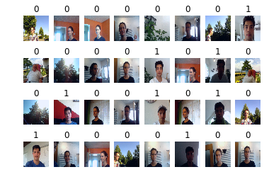

```
=======Validierungsdaten=======
```

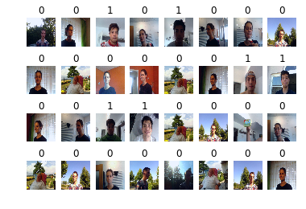

```python
def create_subplot(image_array,label_array,name):
    """Nachfolgende Funktion erstellt aus dem übergebenen Array einen Plot mit 32 zufällig ausgewählten Bildern.

    Args:
        img_array(array): Ist ein Array mit den Bildern als Array.
        y_data(array): Ist ein Array, welches die Label für die Bilder des Array img_array enthält.
        name(str): Ist ein String um dem Abschnitt einen Namen zu geben.
    """
    print("======={}=======".format(name))
    zufall_reihe=np.round(random.sample(range(1, len(label_array)),32))
    i = 0
    for element in zufall_reihe:
        plt.subplot(4,8,i+1)
        img_pro_RGB = cv2.cvtColor(image_array[element], cv2.COLOR_BGR2RGB)
        img_pro= image.array_to_img(img_pro_RGB)
        plt.subplots_adjust(left=None, bottom=None, right=None, top=None,
                wspace=None, hspace=0.5)
        plt.title(int(label_array[element]))
        plt.axis("off")

        plt.imshow(img_pro)
        i+=1
    plt.show()


#1.Step: Gen==========================
create_subplot(x_train_finish,y_train_finish,"Trainingsdaten")
create_subplot(x_val_finish,y_val_finish,"Validierungsdaten")
```

## 6. Neuronales Netz definieren

Zuerst erfolgt die Ladung des vortrainierten Modells "resnet50" ohne der obersten Schicht. Einer der Vorteile des Transferlernens ist, dass mit einer geringen Datenmenge bereits gute Ergebnisse erzielt werden können.  
Grundsätzlich gibt es beim Transferlernen vier mögliche Fälle (http://cs231n.github.io/transfer-learning/). Da beim vorliegenden Fall der Datensatz recht klein und anders ist im Vergleich zum Datensatz mit dem das ResNet50 trainiert wurde, hat sich der Autor für den 3 Fall entschieden d.h. es wird die oberste Schicht ersetzt.  
Zusätzlich zu diesem wird auch noch ein eigenes Netz gebaut, um den direkten Vergleich zu haben.

```python
resnet50_without = ResNet50(input_shape=(224,224,3),include_top=False,weights="imagenet")
```

```python
#1.Step: Laden des vortrainierten neuronalen Netzes
resnet50_without = ResNet50(input_shape=(224,224,3),include_top=False,weights="imagenet")
#2.Step: Es werden bis auf die letzte Schicht alle Gewichte eingefroren, damit diese nicht veränderbar sind.
for layer in resnet50_without.layers[0:len(resnet50_without.layers)-1]: layer.trainable = False


def create_model(resnet50_without,option,optimzer):
    """Nachfolgende Funktion erstellt ein Modell auf Basis von Resnet50.
    Args:
        resnet50_without: Ist ein Array mit den Bildern als Array.
        option(str): Durch Angabe eines Wertes kann das zu erstellende Netz modifiziert werden.
    Return:
        model: Als Rückgabewert bekommt man das neuronale Modell.
    """

    #1.Step: Definierung des Modells
    if  option=="basic":
        x = Flatten()(resnet50_without.output)
        prediction = Dense(1, activation='sigmoid')(x)
        model = Model(inputs=resnet50_without.input, outputs=prediction)
    else:
        x = Flatten()(resnet50_without.output)
        x= Dense(512,activation='relu',kernel_initializer='glorot_uniform')(x)
        x= Dropout(0.1)(x)
        x= Dense(128,activation='relu',kernel_initializer='glorot_uniform')(x)
        x= Dropout(0.1)(x)
        x= Dense(16,activation='relu',kernel_initializer='glorot_uniform')(x)
        prediction = Dense(1, activation='sigmoid')(x)
        model = Model(inputs=resnet50_without.input, outputs=prediction)
    #2.Step: Erstellung des Modells
    model.compile(
      loss='binary_crossentropy',
      optimizer=optimzer,
      metrics=['accuracy']
    )
    return model

model_basic_rmsprop = create_model(resnet50_without,"basic",'rmsprop')
model_basic_adam = create_model(resnet50_without,"basic",'adam')
model_basic_adadelta = create_model(resnet50_without,"basic",'adadelta')
model_more_layer_adam = create_model(resnet50_without,"more_layers",'adam')
model_more_layer_rmsprop = create_model(resnet50_without,"more_layers",'rmsprop')
model_more_layer_adadelta = create_model(resnet50_without,"more_layers",'adadelta')
```

```python
def total_amout_train_para(model):
    """Nachfolgende Funktion berechnet die Anzahl der trainierbaren Parameter eines Modells.
    Args:
        Model: Ist ein neuronales Netz, das auf dem Resnet50 ohne oberste Schicht basiert.
    Return:
        result(int): Summe der trainierbaren Parameter des übergebenen Netzes.
    """
    total_params_resnet = resnet50_without.count_params()
    total_amount_model = model.count_params()
    result = total_amount_model-total_params_resnet
    return result
```

### 7. Training und Optimierung des neuronalen Netzes

Im nachfolgenden Abschnitt erfolgt das Training und die Optimierung des Netzes.

#### 7.1. Training des neuronalen Netzes

Durch das Training lernt das definierte Modell die zugrundeliegende Struktur der Daten kennen. Hierbei werden die Gewichte der einzelne Neuronen modifiziert. Durch die Definierung eines Callbacks soll erreicht werden, dass die beste Gewichtskonstellation abgespeichert wird. Die Abspeicherung erfolgt sobald eine Verbesserung des "val_acc" erzielt wird. Um ein optimales Netz zu finden wurden auch verschiedene Optimierer verwendet. Aufgrund von Vorversuchen wurden die folgende Optimierer ausgesucht:

1. RMSprop: Laut Keras funktioniert dieser Optimierer besonders gut für Recurrent Neural Networks "This optimizer is usually a good choice for recurrent neural networks."
2. Adam
3. Adadelta

Der beste Optimierer wird auch für das eigene Netzwerk genutzt.

```python
def train_model(name,batch_size,model,epochs,x_train, y_train,x_val, y_val):
    """Diese Funktion trainiert ein übergebenes Modell.
    Args:
        name(str):
        batch_size(str): Gibt die Batchgroeße an.
        model: Ist ein Keras-Modell das trainiert wird.
        epochs(int): Gibt die Anzahl der Epochen an.
        x_train(array): Ist ein Array, das die Trainingsdaten enthaelt.
        y_train(array): Ist ein Array mit den Trainingsdaten.
        x_val(array): Ist ein Array mit den Validierungsdaten.
        y_val(array): Ist ein Array mit den Validierungslabels.
    Return:
        Dict: Als Rueckgabewert bekommt man ein Dict, welches das Modell enthält, die Historie, Validierungsgenauigkeit und den Validierungsverlust.
    """
    early_stop_list = ModelCheckpoint("model_weights/best_weights_for_"+name+".h5", monitor='val_acc', verbose=1, save_best_only=True, mode='max')
    callbacks_list = [early_stop_list]

    model_history = model.fit(x_train, y_train, batch_size=batch_size , epochs=epochs, verbose=1,
                              validation_data=(x_val, y_val),shuffle = True,callbacks=callbacks_list)
    (val_loss, val_accuracy) = model.evaluate(x_val, y_val, batch_size=batch_size, verbose=1)
    print(" loss={:.4f}, accuracy: {:.4f}%".format(val_loss,val_accuracy * 100))

    with open('info/trainHistory_'+name, 'wb') as file_pi:
        pickle.dump(model_history.history, file_pi)

    return {"history":model_history,"model":model,"val_loss":val_loss,"val_accuracy":val_accuracy}

#1.Step: Training der verschieden Modelle
information_model_basic_adam = train_model("basic_adam",30,model_basic_adam,10,x_train_finish,y_train_finish,x_val_finish,y_val_finish)
information_model_basic_rmsprop = train_model("basic_rmsprop",30,model_basic_rmsprop,10,x_train_finish,y_train_finish,x_val_finish,y_val_finish)
information_model_basic_adadelta = train_model("basic_adadelta",30,model_basic_adadelta,10,x_train_finish,y_train_finish,x_val_finish,y_val_finish)

information_model_more_layer_adam= train_model("more_layer_adam",30,model_more_layer_adam,10,x_train_finish,y_train_finish,x_val_finish,y_val_finish)
information_model_more_layer_rmsprop= train_model("more_layer_rmsprop",30,model_more_layer_rmsprop,10,x_train_finish,y_train_finish,x_val_finish,y_val_finish)
information_model_model_more_layer_adadelta= train_model("more_layer_adadelta",30,model_more_layer_adadelta,10,x_train_finish,y_train_finish,x_val_finish,y_val_finish)
```

```
Train on 1211 samples, validate on 302 samples
```

#### 7.2 Visualisierung der "val_acc" und "train_acc" der Modelle

Durch den Verlauf von "val_acc" und "train_acc" können Rückschlüsse auf den Traingsverlauf gezogen werden. Allerdings kann aufgrund der geringen Epochenzahl kein verlässlicher Rückschluss gezogen werden, ob ein Overfitting vorliegt. Um die gleichen Graphen wie der Autor zu bekommen müssen die Daten aus dem Ordner "history" geladen werden.

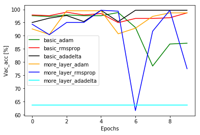

```
Val_acc in the last epoch
more_layer_adadelta: 63.757%, Train_Para: 51,448,481
more_layer_rmsprop: 77.483%, Train_Para: 51,448,481
basic_adam: 87.164%, Train_Para: 100,353
more_layer_adam: 98.677%, Train_Para: 51,448,481
basic_rmsprop: 98.681%, Train_Para: 100,353
basic_adadelta: 99.669%, Train_Para: 100,353
```

```python
def show_charts(case):
    """Mit dieser Funktion wird ein Liniendiagramm mit den "val_acc" aller Modelle geplottet.

    Args:
        case (str): Angabe des Falls. In dem das Wort „aktuell“ angeben wird, werden die Graphen der aktuellen Session  gezeigt. Diese befinden sich im Ordner „info“.
    """
    if case == "aktuell":
       path = "info"
    else:
        path = "history"
    #1.Step: Laden der History der Modell==============
    history_basic_adam = pickle.load( open(path+"/trainHistory_basic_adam", "rb" ) )
    history_basic_rmsprop = pickle.load( open( path+"/trainHistory_basic_rmsprop", "rb" ) )
    history_basic_adadelta = pickle.load( open( path+"/trainHistory_basic_adadelta", "rb" ) )

    history_more_layer_adam = pickle.load( open( path+"/trainHistory_more_layer_adam", "rb" ) )
    history_more_layer_rmsprop = pickle.load( open( path+"/trainHistory_more_layer_rmsprop", "rb" ) )
    history_more_layer_adadelta = pickle.load( open(path+"/trainHistory_more_layer_adadelta", "rb" ) )
    #2.Step: Jeden Wert mit 100 multiplizieren und auf die dritte Stelle nach dem Punkt runden.
    history_basic_adam['val_acc'] = [ np.round(x*100,3) for x in history_basic_adam['val_acc']]
    history_basic_rmsprop['val_acc'] = [ np.round(x*100,3) for x in history_basic_rmsprop['val_acc']]
    history_basic_adadelta['val_acc'] = [ np.round(x*100,3) for x in history_basic_adadelta['val_acc']]

    history_more_layer_adam['val_acc'] = [ np.round(x*100,3) for x in history_more_layer_adam['val_acc']]
    history_more_layer_rmsprop['val_acc'] = [ np.round(x*100,3) for x in history_more_layer_rmsprop['val_acc']]
    history_more_layer_adadelta['val_acc'] = [ np.round(x*100,3) for x in history_more_layer_adadelta['val_acc']]

    #3.Step: Plottet die "val_acc" aller Modelle über das gesamte Training.
    plt.plot(history_basic_adam['val_acc'],color='green')
    plt.plot(history_basic_rmsprop['val_acc'],color='red')
    plt.plot(history_basic_adadelta['val_acc'],color='black')

    plt.plot(history_more_layer_adam['val_acc'],color='orange')
    plt.plot(history_more_layer_rmsprop['val_acc'],color='blue')
    plt.plot(history_more_layer_adadelta['val_acc'],color='cyan')
    plt.legend(['basic_adam','basic_rmsprop',"basic_adadelta",'more_layer_adam','more_layer_rmsprop',"more_layer_adadelta"])
    plt.xlabel("Epochs")
    plt.ylabel("Vac_acc [%]")
    plt.figure(figsize=(40,40))
    plt.show()
    #3.Step: Die "val_acc" von jedem Modell wird mit Namen in einem Dict gespeichert.============
    dict_vac_acc_last_epoch = {
     "basic_adam":[np.round(history_basic_adam['val_acc'][-1],3),total_amout_train_para(model_basic_adam)],
     "basic_rmsprop":[np.round(history_basic_rmsprop['val_acc'][-1],3),total_amout_train_para(model_basic_rmsprop)],
     "basic_adadelta":[np.round(history_basic_adadelta['val_acc'][-1],3),total_amout_train_para(model_basic_adadelta)],

     "more_layer_adam":[np.round(history_more_layer_adam['val_acc'][-1],3),total_amout_train_para(model_more_layer_adam)],
     "more_layer_rmsprop":[np.round(history_more_layer_rmsprop['val_acc'][-1],3),total_amout_train_para(model_more_layer_rmsprop)],
     "more_layer_adadelta":[np.round(history_more_layer_adadelta['val_acc'][-1],3),total_amout_train_para(model_more_layer_rmsprop)]}

    #4.Step: Das Dict wird sortiert nach dem ersten Item und als Liste abgespeichert.
    sorted_vac_acc_last_epoch = sorted(dict_vac_acc_last_epoch.items(), key=operator.itemgetter(1))
    #5.Step: Die Liste wird ausgedruckt.
    print("Val_acc in the last epoch")
    for name, val_acc, in sorted_vac_acc_last_epoch:
        print("{0}: {1}%, Train_Para: {2:,}".format(name, val_acc[0],val_acc[1]))

show_charts("Autor_Graphen")
```

Schön zu erkennen ist, dass Modelle mit einer höheren Anzahl von trainierbaren Parametern nicht zwangsläufig bessere Validierungsgenauigkeiten ("val_acc") aufweisen. Im Schnitt waren die Modelle mit trainierbaren Parametern im Millionenbereich deutlich schlechter als die anderen Modelle. Generell wurde festgestellt, dass die neuronalen Netze immer wieder anders konvergieren.

#### 7.3 Erstellung eines eigenen Netzes

Das eigene Netz wird in Form eines convolutional Netzes aufgebaut, da sich diese Form besonders gut für die Verarbeitung von Bildern eignet. Es wird der Optimierer „Adadelta“ verwendetet, da das Netz mit der bisherigen besten Validierungsgenauigkeit den selbigen verwendet. Zudem wurde darauf geachtet, die Anzahl der Parameter gering zu halten z.B. durch die Verwendung von weniger Neuronen pro Schicht oder einer größeren pool_size bei MaxPooling2D Schichten. Ein Grund hierfür war, dass dadurch die Trainingszeit reduziert wird.

```python
#1.Step: Definition des eigenen Modells
input_shape=(224,224,3)

model_owne = Sequential()
model_owne.add(Conv2D(32, kernel_size=(3, 3), strides=(1, 1),
                 activation='relu',
                 input_shape=input_shape))
model_owne.add(MaxPooling2D(pool_size=(4, 4), strides=(2, 2)))
model_owne.add(Conv2D(64, (5, 5), activation='relu'))
model_owne.add(MaxPooling2D(pool_size=(6, 6)))
model_owne.add(Flatten())
model_owne.add(Dense(128, activation='relu'))
model_owne.add(Dropout(0.2))
model_owne.add(Dense(1, activation='sigmoid'))

#2.Step: Das Modell erstellen
model_owne.compile(
  loss='binary_crossentropy',
  optimizer="adadelta",
  metrics=['accuracy']
)
#3.Step: Modell trainieren
information_model_owne=train_model("owne",30,model_owne,10,x_train_finish,y_train_finish,x_val_finish,y_val_finish)
```

#### 7.4 Vergleich des eigenen Netzwerks mit dem besten transfer. Netz

```
['.ipynb_checkpoints', 'data', 'Face_Reg_Gustav_Willig.html', 'Face_Reg_Gustav_Willig.ipynb', 'Gustav', 'history', 'info', 'model_weights', 'other']
```

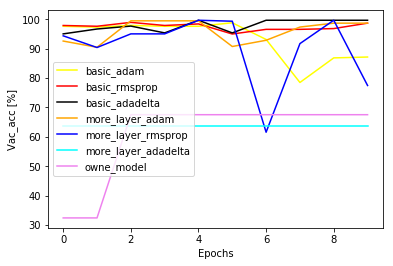

```
Val_acc in the last epoch
more_layer_adadelta: 63.757%, Train_Para: 51,448,481
owne_model: 67.55%, Train_Para: 2,419,905
more_layer_rmsprop: 77.483%, Train_Para: 51,448,481
basic_adam: 87.164%, Train_Para: 100,353
more_layer_adam: 98.677%, Train_Para: 51,448,481
basic_rmsprop: 98.681%, Train_Para: 100,353
basic_adadelta: 99.669%, Train_Para: 100,353
```

```python
#1.Step: Laden der History der Modell==============
liste=os.listdir(os.getcwd())
print(liste)

def show_charts(case):
    """Mit dieser Funktion wird ein Liniendiagramm mit den "val_acc" aller Modelle geplottet.

    Args:
        case (str): Angabe des Falls. In dem das Wort „aktuell“ angeben wird, werden die Graphen der aktuellen Session  gezeigt. Diese befinden sich im Ordner „info“.
    """
    if case == "aktuell":
       path = "info"
    else:
        path = "history"
    history_basic_adam = pickle.load( open(path+"/trainHistory_basic_adam", "rb" ) )
    history_basic_rmsprop = pickle.load( open( path+"/trainHistory_basic_rmsprop", "rb" ) )
    history_basic_adadelta = pickle.load( open( path+"/trainHistory_basic_adadelta", "rb" ) )

    history_more_layer_adam = pickle.load( open( path+"/trainHistory_more_layer_adam", "rb" ) )
    history_more_layer_rmsprop = pickle.load( open( path+"/trainHistory_more_layer_rmsprop", "rb" ) )
    history_more_layer_adadelta = pickle.load( open(path+"/trainHistory_more_layer_adadelta", "rb" ) )
    history_owne_model = pickle.load( open( path+"/trainHistory_owne", "rb" ) )

    #2.Step: Jeden Wert mit 100 multiplizieren und auf die dritte Stelle nach dem Punkt runden.
    history_basic_adam['val_acc'] = [ np.round(x*100,3) for x in history_basic_adam['val_acc']]
    history_basic_rmsprop['val_acc'] = [ np.round(x*100,3) for x in history_basic_rmsprop['val_acc']]
    history_basic_adadelta['val_acc'] = [ np.round(x*100,3) for x in history_basic_adadelta['val_acc']]

    history_more_layer_adam['val_acc'] = [ np.round(x*100,3) for x in history_more_layer_adam['val_acc']]
    history_more_layer_rmsprop['val_acc'] = [ np.round(x*100,3) for x in history_more_layer_rmsprop['val_acc']]
    history_more_layer_adadelta['val_acc'] = [ np.round(x*100,3) for x in history_more_layer_adadelta['val_acc']]
    history_owne_model['val_acc'] = [ np.round(x*100,3) for x in history_owne_model['val_acc']]

    #==============
    #2.Step: Plottet die "val_acc" aller Modelle über das gesamte Training.    plt.plot(history_basic_adam['val_acc'],color='green')
    plt.plot(history_basic_adam['val_acc'],color='yellow')
    plt.plot(history_basic_rmsprop['val_acc'],color='red')
    plt.plot(history_basic_adadelta['val_acc'],color='black')

    plt.plot(history_more_layer_adam['val_acc'],color='orange')
    plt.plot(history_more_layer_rmsprop['val_acc'],color='blue')
    plt.plot(history_more_layer_adadelta['val_acc'],color='cyan')

    plt.plot(history_owne_model['val_acc'],color='violet')

    plt.legend(['basic_adam','basic_rmsprop',"basic_adadelta",'more_layer_adam','more_layer_rmsprop',"more_layer_adadelta","owne_model"])
    plt.xlabel("Epochs")
    plt.ylabel("Vac_acc [%]")
    plt.figure(figsize=(40,40))
    plt.show()
    #3.Step: Die "val_acc" von jedem Modell wird mit Namen in einem Dict gespeichert.============
    dict_vac_acc_last_epoch = {
     "basic_adam":[np.round(history_basic_adam['val_acc'][-1],3),total_amout_train_para(model_basic_adam)],
     "basic_rmsprop":[np.round(history_basic_rmsprop['val_acc'][-1],3),total_amout_train_para(model_basic_rmsprop)],
     "basic_adadelta":[np.round(history_basic_adadelta['val_acc'][-1],3),total_amout_train_para(model_basic_adadelta)],

     "more_layer_adam":[np.round(history_more_layer_adam['val_acc'][-1],3),total_amout_train_para(model_more_layer_adam)],
     "more_layer_rmsprop":[np.round(history_more_layer_rmsprop['val_acc'][-1],3),total_amout_train_para(model_more_layer_rmsprop)],
     "more_layer_adadelta":[np.round(history_more_layer_adadelta['val_acc'][-1],3),total_amout_train_para(model_more_layer_rmsprop)],
     "owne_model":[np.round(history_owne_model['val_acc'][-1],3),model_owne.count_params()]}

    #4.Step: Das Dict wird sortiert nach dem ersten Item und als Liste abgespeichert.
    sorted_vac_acc_last_epoch = sorted(dict_vac_acc_last_epoch.items(), key=operator.itemgetter(1))

    #5.Step: Die Liste wird ausgedruckt.
    print("Val_acc in the last epoch")
    for name, val_acc, in sorted_vac_acc_last_epoch:
        print("{0}: {1}%, Train_Para: {2:,}".format(name, val_acc[0],val_acc[1]))

show_charts("Autor_Graphen")
```

Wie man gut an dem Graph erkennen kann, ist das eigene Netzwerk bedeutend schlechter als das beste Modell "basic_adadelta". Zudem weist es auch eine deutlich höhere Anzahl an trainierbaren Parametern zu diesem auf. Dies kann zu einer geringeren Effizienz führen, aufgrund des höheren Zeitbedarfs für das Training und bei Prädiktionen.

#### 7.5 Optimierung des Netzwerkes

Um die Validierungsgenauigkeit („val_acc“) des Netzwerkes zu erhöhen kann eine Vielzahl von Maßnahmen ergriffen werden.

- Bessere Aufbereitung der Trainings- und Validierungsdaten
- Optimierung der Hyperparameter
- Erhöhung der Anzahl der Trainings- und Validierungsdaten

##### 7.5.1 Verbessere Aufbereitung der Trainings- und Validierungsdaten

Ein Fehler den der Autor erst im Nachhinein behoben hat, war das die Trainings- und Validierungsdaten nach dem Entstehungsdatum sortiert waren. Durch eine Zufallsverteilung der Daten konnte dieser Umstand behoben werden und die Validierungsgenauigkeit bei allen Modellen deutlich verbessert werden.

##### 7.5.2 Optimierung der Hyperparameter

Neben der Möglichkeit per Hand die optimalen Hyperparameter für ein Netzwerk zu finden (wie hier mit dem Optimierer) gibt es auch von sklearn die Funktion GridSearch.  
Mit Hilfe der Funktion GridSearchCV können verschiedene Parameter ausprobiert werden um die optimale Kombination zu finden. Angelehnt an https://machinelearningmastery.com/grid-search-hyperparameters-deep-learning-models-python-keras/

##### Fazit zu GridSearch

Nach etlichen Stunden musste der Autor leider feststellen, dass aufgrund der Limitationen der Hardware (32 GB Arbeitsspeicher, Intel(R) Core i7-4810MQ CPU @2.80 GHZ, NVIDIA Quadro K2100M), der Einsatz von GridSearch auf dem Laptop nicht möglich ist ohne von Jupyter-notebook den Error ResourceExhaustedError zu bekommen. Aus diesem Grund hat der Autor den optimalen Optimierer per Hand bestimmt. Da die Validierungsgenauigkeit des Netzes bereits bei ca. 99% lag, wurde auf eine weitere Optimierung der Hyperparameter verzichtet.

#### 7.5.3 Erhöhung der Anzahl der Trainings- und Validierungsdaten

Die dritte Möglichkeit die Validierungsgenauigkeit zu verbessern besteht in der Erhöhung der Anzahl der Trainings - und Validierungsdaten. Hierfür gibt es grundsätzlich zwei Möglichkeiten. Entweder man sammelt per Hand mehr Daten oder man setzt Generatoren ein, welche durch die Veränderung der bestehenden Daten neue Datensätze generieren. Nachfolgend wird versucht mit den Generatoren die Validierungsgenauigkeit des Modells "model_basic_adadelta" zu verbessern. Die Einstellungen für den ImageGenDataGeneror wurden teilweise aus dem Jupyter-Notebook  
"Transferlearning_Fruits_Example_Solution" entnommen.

```python
#1.Step:Festlegung der Parameter==========
batch_size=50
epochs = 10
steps_per_epoch=number_of_train_img // batch_size
validation_steps=(number_val_other+number_val_self) // batch_size

generator = ImageDataGenerator(
  rotation_range=10,
  width_shift_range=0.1,
  height_shift_range=0.1,
  shear_range=0.1,
  zoom_range=0.2,
  horizontal_flip=True,
  vertical_flip=True,
  preprocessing_function=preprocess_input
)

"""#2.Step Generierung von zwei Generatoren. Einer für die Trainingsdaten und ein Anderer für die
Validierungsdaten.Somit kann in Echtzeit „Data Augmentation“ betrieben werden."""
train_generator = generator.flow_from_directory(
  "data/train",
  target_size=procced_image_size,
  shuffle=True,
  batch_size=batch_size,
  class_mode='binary'
)

valid_generator = generator.flow_from_directory(
  "data/val",
  target_size= procced_image_size,
  shuffle=True,
  batch_size=batch_size,
  class_mode='binary'
)

#
generator_model_history = model_basic_adadelta.fit_generator(
    train_generator,
    validation_data=valid_generator,
    epochs=epochs,
    steps_per_epoch=steps_per_epoch,
    validation_steps=validation_steps,
    verbose=1,

)
#3.Step: Speicherung der Trainingshistorie des Generators
with open('info/trainHistory_generator', 'wb') as file_pi:
    pickle.dump(generator_model_history.history, file_pi)
```

```
Found 1211 images belonging to 2 classes.
Found 302 images belonging to 2 classes.
```

[output not shown]

[output cut: 16 more lines]

[output not shown]

```python
def create_new_files(path,nr=1):
    """
    Mit dieser Funktion kann der vorhandene Datenbestand vergrößert werden.

    Args:
        Path(string): Gibt den Pfad zu den Originaldaten an.
        nr: Ist die Anzahl der generierten Daten aus einem Originaldatensatz.

    Notiz:
        nr=3 bedeutet aus einem Originalbild entstehen 3 neue Bilder.
    """
    #1.Step: Auflistung aller Elemente in dem angegebenen Pfad
    files_in_folder = os.listdir(path)
    #2.Step: Durch eine Schleife wird jedes Element aus dem Pfad an den Generator übergeben
    for element in files_in_folder:
        img_file = load_img(path+"/"+element)
        img_file = img_to_array(img_file)
        img_file = img_file.reshape((1,) + img_file.shape)
        i = 0
        for batch in gen.flow(img_file, batch_size=1,save_to_dir='imgen/', save_prefix='gen', save_format='jpeg'):
            i += 1
            if i > nr:
                break
```

### 8. Interpretation des Trainings des besten Modells

In diesem Abschnitt wird das Modell "basic_adadelta" mit der besten Validierungsgenauigkeit genauer analysiert, um ein besseres Verständnis über dieses zu gewinnen. Zunächst werden einige nützliche Funktionen definiert.

```python
"""Diese Funktion plot_confusion_matrix wurde nicht selbst geschrieben! Sondern von folgender Seite bezogen:
http://scikit-learn.org/stable/auto_examples/model_selection/plot_confusion_matrix.html#sphx-glr-auto-examples-model-selection-plot-confusion-matrix-py"""

def plot_confusion_matrix(cm,
                          normalize=False,
                          title='Confusion matrix',
                          cmap=plt.cm.Blues):
    """
    This function prints and plots the confusion matrix.
    Normalization can be applied by setting `normalize=True`.
    """
    if normalize:
        cm = cm.astype('float') / cm.sum(axis=1)[:, np.newaxis]
        print("Normalized confusion matrix")
    else:
        print('Confusion matrix, without normalization')

    print(cm)

    plt.imshow(cm, interpolation='nearest', cmap=cmap)
    plt.title(title)
    plt.colorbar()
    tick_marks = np.arange(len(["",""]))
    plt.xticks(tick_marks, ["Negativ","Positiv"], rotation=45)
    plt.yticks(tick_marks, ["False","True"])

    fmt = '.2f' if normalize else 'd'
    thresh = cm.max() / 2.
    for i, j in itertools.product(range(cm.shape[0]), range(cm.shape[1])):
        plt.text(j, i, format(cm[i, j], fmt),
                 horizontalalignment="center",
                 color="white" if cm[i, j] > thresh else "black")
    plt.tight_layout()
    plt.ylabel('True')
    plt.xlabel('Predicted')
    plt.figure(figsize=(1,1))

def conf_matrix_index(y_true, y_pred):
    """Die Funktion gibt den genauen Index für die verschieden Fälle (TP,FP,TN FN) an,
    welches ein Element in den Validierungsdaten (x_val_finish) hat.
    Args:
        y_true(array): Array mit den wahren Labels (y_val_finish)
        y_pred(array): Array mit den vorhergesagten Labels.

    Return:
        Dict: Als Rückgabewert bekommt man ein Dict mit den Indexen für die Fälle TP, FP, TN und FN
    """

    TP = []
    FP = []
    TN = []
    FN = []

    for i in range(len(y_pred)):
        if y_true[i]==y_pred[i]==1:
           TP.append(i)
        if y_pred[i]==1 and y_true[i]!=y_pred[i]:
           FP.append(i)
        if y_true[i]==1 and y_pred[i]==0:
           TN.append(i)
        if y_pred[i]==0 and y_true[i]!=y_pred[i]:
           FN.append(i)
    return {"TP":TP,"FP":FP,"TN":TN,"FN":FN}

def plot_case(case,name,y_predict):
    """Die Funktion plottet die Bilder für einen ausgewählten Fall.

    Args:
        case(list): Angabe des Falles der angezeigt werden soll z.B. Case=TP
        name(str): Gibt den Namen für den Bereich an.
        y_predict(array): Array mit den vorausgesagten Labels.
    """

    print("======={}=========".format(name))
    i=0
    for element in case:
        plt.subplot(len(case),2,i+1)
        plt.axis("off")
        plt.subplots_adjust(left=None, bottom=None, right=None, top=None,
        wspace=1, hspace=0.5)
        img_pro_RGB = cv2.cvtColor(x_val_finish[element], cv2.COLOR_BGR2RGB)
        img_pro= image.array_to_img(img_pro_RGB)
        plt.imshow(img_pro)
        plt.title("Index: {}, Predict: {}".format(element,y_predict[element]))
        i+=1
    plt.show()
```

Im nächsten Schritt erfolgt die genaue Untersuchung des besten Modells d.h.

- Berechenung der "Null Accuracy"
- Plotten der Confusion Matrix Um eine Aussage über die Genauigkeit des besten Modells treffen zu können, muss zuerst die "Null accuracy" ermittelt werden. Als "Null accuracy" bezeichnet man die Genauigkeit die das Modell erzielen würde, wenn es einfach nur auf die Klasse tippt, welche am häufigsten vorkommt.

```python
#1.Step: Bestimmung der "Null Accuracy":
null_accurcay = max(y_val_finish.mean(), 1 - y_val_finish.mean())
print("Null accuracy: ",null_accurcay)
#Die "Null accuracy" in dieser Form zu berechnen, funktioniert nur bei binären Klassifikationsproblemen.
```

```
Null accuracy:  0.6754966887417219
```

Wie ersichtlich ist, ist die Validierungsgenauigkeit des Modells "basic_adadelta" deutlich höher, was ein klares Zeichen dafür ist, dass das Modell die zugrundeliegende Struktur verstanden hat. Als nächstes wird die Confusion Matrix betrachtet, um einen genaueren Einblick zu erhalten, wie das Modell entschieden hat.

```
Confusion matrix, without normalization
[[203   1]
 [  0  98]]
             precision    recall  f1-score   support

      Other       1.00      1.00      1.00       204
       Self       0.99      1.00      0.99        98

avg / total       1.00      1.00      1.00       302
```

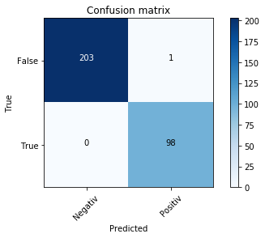

```python
def confusion_matrix_plotten(case,model=None):
    """Mit dieser Funktion wird für eine Confusion Matrix  für das übergebene Modell geplottet.
    Args:
        case(str): Wenn "aktuell" angegeben wird, wird für das aktuelle Modell die Confusion-Matrix
                berechnet und geplottet. Wenn nichts eingetragen ist,
                werden die Werte des Autors geplottet.
        model: Ist das Modell, das genommen werden soll.
                Bei keiner Angabe wird das Modell des Autors verwendet.
    Return:
            y_predict_proc(array): Array, das die gerundeten vorhergesagten Labels enthält.
            y_predict(array): Array, das die vorhergesagten Labels enthält.
    Notiz:
        Die Graphen der aktuellen Session sind im Ordner "info" gespeichert.
        Mit Angabe des Wortes "aktuell" bei path_folder werden die aktuellen Graphen gezeigt.
    """
    if case =="aktuell":
        #1.Step: Laden der Gewichte des Modells, welches das beste Resultat während des Traings erzielt hat======
        model=model.load_weights('info//'+str(model)+'.h5')
        #2.Step: Voraussage der Labels
        y_predict = model.predict(x_val_finish)
        #3.Step: Ganzzahlige Rundung des Arrays y_predict
        y_predict_proc = np.round(y_predict)
        #3.Step: Erstellung der Conusion Matrix und plotten des Ergebnisses
        corr = confusion_matrix(y_val_finish,y_predict_proc)

        plot_confusion_matrix(corr)
        print(classification_report(y_val_finish,y_predict_proc,target_names = ["Other","Self"]))
        return y_predict,y_predict_proc
    else:
        #Alternativ
        #1.Step: Laden der Werte des Autors
        y_predict = pickle.load( open("history/y_predict", "rb" ) )
        y_predict_proc = np.round(y_predict)
        corr = confusion_matrix(y_val_finish,y_predict_proc)
        #2.Step:Erstellung der Conusion Matrix und plotten des Ergebnisses
        plot_confusion_matrix(corr)
        print(classification_report(y_val_finish,y_predict_proc,target_names = ["Other","Self"]))

        return [y_predict,y_predict_proc]

[y_predict,y_predict_proc]=confusion_matrix_plotten("history")
```

###### 8.2.1 Plotten der TN und FP

Als nächstes werden die TN und FP des Modell geplotten um zu sehen, in welchen Fällen das Modell fehler gemacht hat.

```
=======True-Negativ=========
=======False-Positiv=========
```

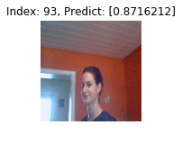

```python
#Plotten der Bilder die TN bzw. FP sind
index_corr = conf_matrix_index(y_val_finish,y_predict_proc)

plot_case(index_corr["TN"],"True-Negativ",y_predict)
plot_case(index_corr["FP"],"False-Positiv",y_predict)
```

Interessanterweise hat das Modell einmal die weibliche Person fälschlicherweise als den Autor erkannt. Da es sich jedoch nur um ein Bild handelt, geht der Autor davon aus, dass die Falschklassifikation auf die 1% Fehlerquote zurückzuführen ist.

###### 8.3 Testen des Netzwerkes mit unbekannten Bildern

Um den Trainingsverfolg zu bestätigen, befindet sich im Ordner "daten" noch ein Ordner mit Testbildern. Mit Hilfe der Testbildern kann kontrolliert werden, ob das Netz tatsächlich das Muster gelernt hat, um den Autor zu erkennen.

[figure not shown]

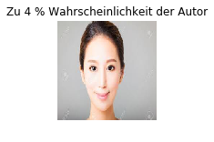

[figure not shown]

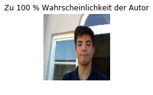

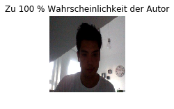

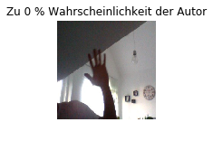

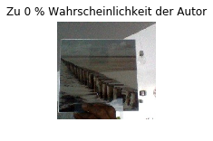

```python
#1.Step: Festlegung der Parameter==========
img_list_folder = os.listdir("data/test")

element_image= img_list_folder[1]
img_path = ("data/test"+ "/"+element_image)
img_original = image.load_img(img_path,target_size=(224,224))
img_proccessed = image.array_to_img(img_original)
img_proccessed = np.expand_dims(img_proccessed, axis=0)
img_list_folder = os.listdir("data/test")
model_basic_adadelta.load_weights('history/best_weights_for_model_basic_adadelta.h5')
model=model_basic_adadelta
#2.Step: Jedes Bild im Ordner wird zur Vohersage des Labels an das Netz uebergeben
i=0
for element_image in img_list_folder:
    plt.figure(figsize=(20,20))
    plt.subplot(7,2,i+1)

    img_path = ("data/test"+ "/"+element_image)
    #3.Step:Laed das Image in einem bestimmten Format
    if element_image == "Thumbs.db":
        continue
    plt.subplots_adjust(left=None, bottom=None, right=None, top=None,
    wspace=1, hspace=0.5)
    plt.axis("off")
    img_original = image.load_img(img_path,target_size=(224,224))
    img_proccessed = image.img_to_array(img_original)#!!!
    img_proccessed = np.expand_dims(img_proccessed, axis=0)
    img_proccessed = preprocess_input(img_proccessed)
    plt.imshow(img_original)
    predict=model.predict(img_proccessed)
    plt.title("Zu {} % Wahrscheinlichkeit der Autor".format(int(predict[-1]*100)))
    i+=1
    plt.show()
```

Wie gut zu sehen ist, kann das Modell den Autor von anderen Personen und Objekten klar unterscheiden.

### 9. Fazit

Ein wichtiger Schritt um erfolgreich ein neuronales Netz zu trainieren besteht in der Datenaufbereitung. Zudem muss bei der Auswahl der Daten darauf geachtet werden, dass diese ausgewogen und repräsentativ sind. Zu Beginn gab es zu viele Aufnahmen des Autors im selben T-Shirt, was dazu geführt hat, dass das Netz abhängig von der T-Shirt Farbe entschieden hat, ob es sich um den Autor handelt oder nicht. Außerdem hat der Autor die Erfahrung gemacht, dass Netze mit einer sehr großen Anzahl von trainerbaren Parametern im Durchschnitt eher schlechter abschneiden als besser. Durch eine reine Vergrößerung der Anzahl der Neuronen wird ein neuronales Netz nicht besser, was sich auch mit den in der Vorlesung vermittelten Informationen deckt. Zudem ist das Training sehr zeitaufwendig sowie die Suche nach den optimalen Parametern. Deswegen sollte versucht werden die Anzahl der Schichten so gering wie möglich zu halten, damit das Training so kurz wie möglich ist. Zusätzlich ist dem Autor aufgefallen, was jedoch auch in der Vorlesung vermittelt wurde, dass neuronale Netzte immer anders konvergieren, was dazu führt, dass je nach Durchgang eine andere Konstellation von Hyperparameter die Optimale sein kann.